# correlation_core_genes_with_PTR

ASintsova

4/19/2017

## Goal: see if gene expression correlates with PTR for five human UTI samples

1. Going to look at ribosomal gene expression, since that had phylogenetic signal + highly expressed + should cluster close to origin of replication
2. Do an unbiased search for genes whose expression correlated with PTR values
3. Look at chromosomal location of all these genes with relation to the origin/terminus of replication

## 1 Look at ribosomal gene expression, since that had phylogenetic signal + highly expressed + should cluster close to origin of replication

- Load in the data

```
##       PTR   GR Doub.time
## HM14 2.12 1.79      23.2
## HM17 2.29 2.08      20.0
## HM56 1.78 1.21      34.4
## HM66 2.38 2.22      18.7
## HM68 2.44 2.32      17.9
```

- Plot mean ribosomal gene expression for urine and uti samples

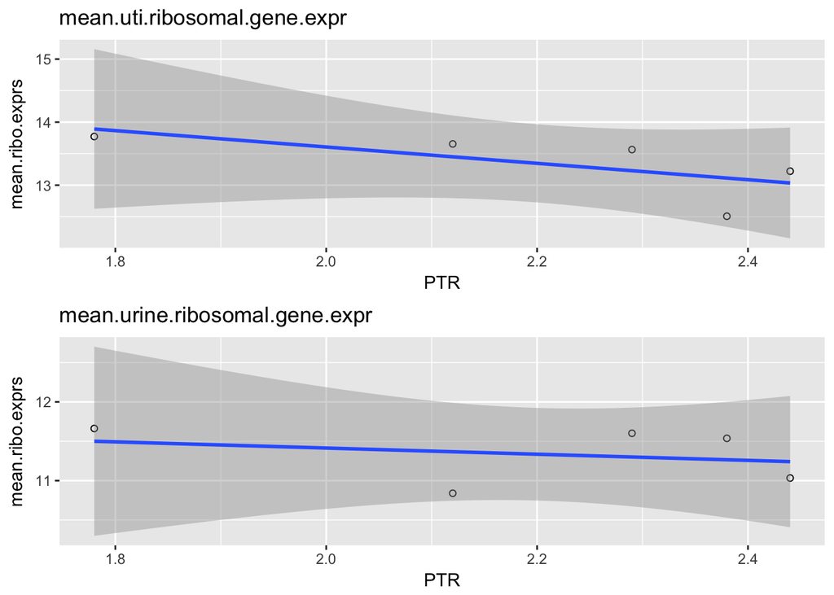

- Look at individual ribosomal genes: fit linear model, run an anova, anova p-vals are displayes

```
##          gene               pval
## 31 16442_rplD 0.0652293209339739
## 8  16361_rpsI 0.0723405502463015
## 46 17312_rpsR  0.079258888970813
## 35 16451_rpsL 0.0838388916959329
## 32 16443_rplC  0.107062705680605
## 18 16428_rplF  0.107910105322768
## 23 16433_rplN  0.124630201567598
## 14 16422_rpmJ  0.151861260596234
## 26 16436_rplP  0.161673474030866
## 21 16431_rplE  0.166897899709128
## 29 16439_rpsS  0.167260149607068
## 49 17722_rpsB  0.167267205988365
## 44 17274_rsgA  0.169449886888506
## 27 16437_rpsC  0.181659592450026
```

[output cut: 38 more lines]

- A few are on the verge of significance, this doesn’t indicate whether correlation is positive or negative
- Examples

```
## [1] "16442_rplD"
```

```
## [1] "17312_rpsR"
```

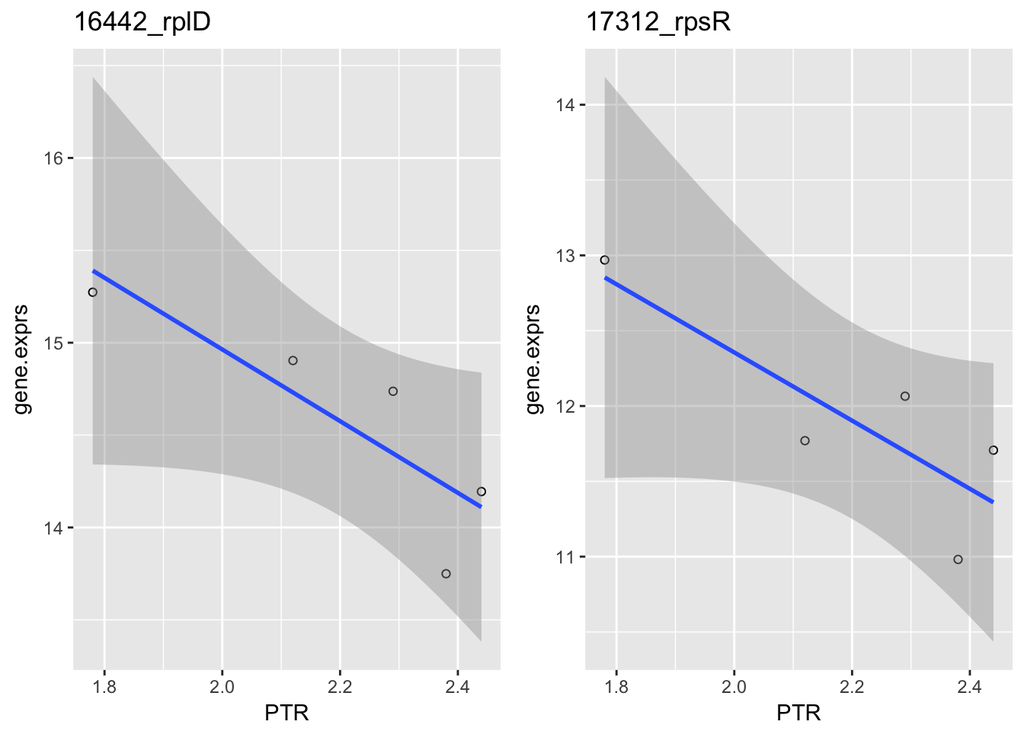

- Looks like if anything the correlation is negative…

## 2 Do an unbiased search for genes whose expression correlated with PTR values

- Load the data

```
##       PTR   GR Doub.time
## HM14 2.12 1.79      23.2
## HM17 2.29 2.08      20.0
## HM56 1.78 1.21      34.4
## HM66 2.38 2.22      18.7
## HM68 2.44 2.32      17.9
```

```
##                               UTI14    UTI17    UTI56    UTI66    UTI68
## 14805_sufB_1               7.715508 7.069548 8.411683 9.036013 9.454497
## 14806_iscA_1               5.030177 5.935690 6.919761 8.230718 7.980117
## 14807_hypothetical_protein 6.877073 6.761783 8.004449 6.245055 8.456552
## 14808_ydiI_1               6.148266 6.211633 7.089698 7.235513 6.504939
## 14817_aroD_1               6.196092 5.145905 6.251211 7.235513 4.804571
## 14818_ydiF_1               4.047832 4.744387 3.966340 6.245055 4.245192
```

- Find genes correlating with PTR

```
##                            gene                 pval               int
## 783                   16489_gph 0.000186926423027505  19.0165898949492
## 1304                 17560_thrB 0.000752634108448298  5.40159973338952
## 286  15460_hypothetical_protein   0.0012322775210068 -1.64869611376888
## 1007 16925_hypothetical_protein  0.00170369314563776 -4.62960906379681
## 1192                 17254_groL  0.00407235404549098   11.381112532281
## 1934                 18964_nhoA  0.00412293326263478 0.853296336058906
```

- Save the Results
- Examples:

```
## [1] "18964_nhoA"
```

```
## [1] "17254_groL"
```

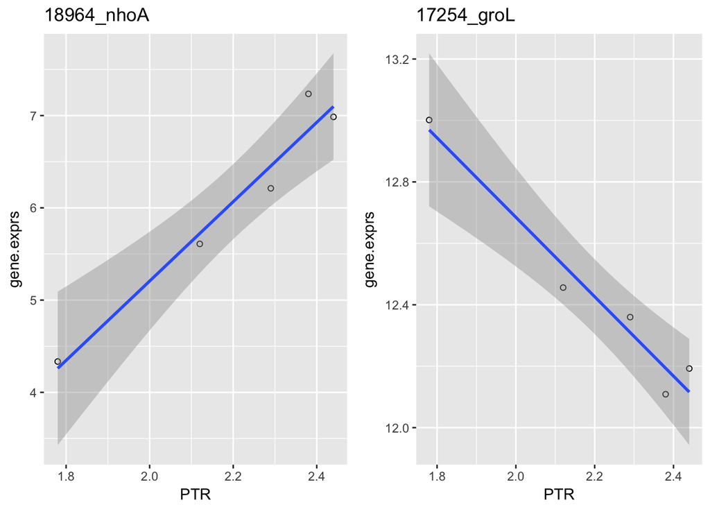

## 3 Look at chromosomal location of all these genes with relation to the origin/terminus of replication

### Ribosomal Genes

- Load in the locations (see comments below about accuracy)
- Origin - red, terminus - blue, rpsI - orange, rpsL - magenta, rplD - green
- HM14

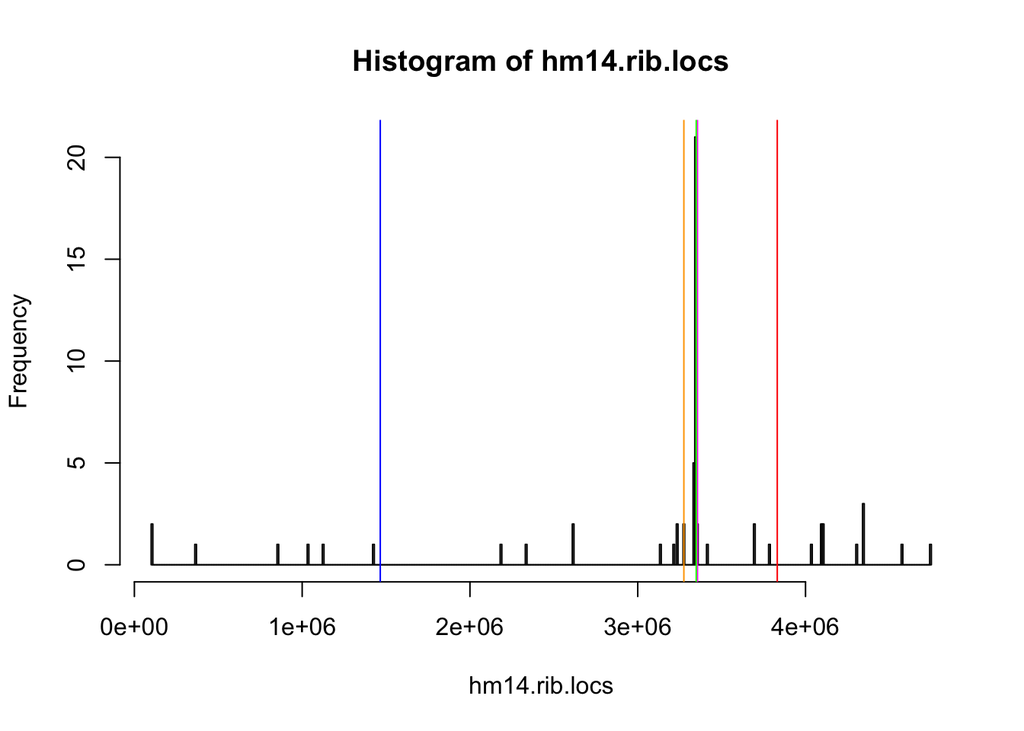

- HM56

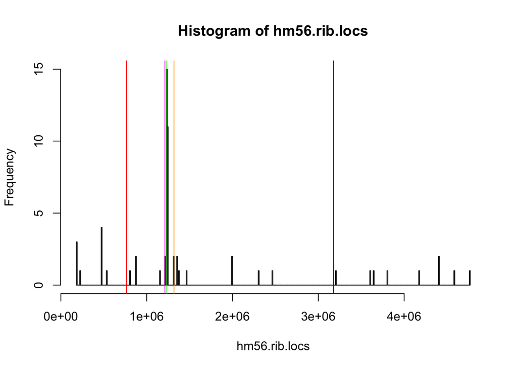

- HM3

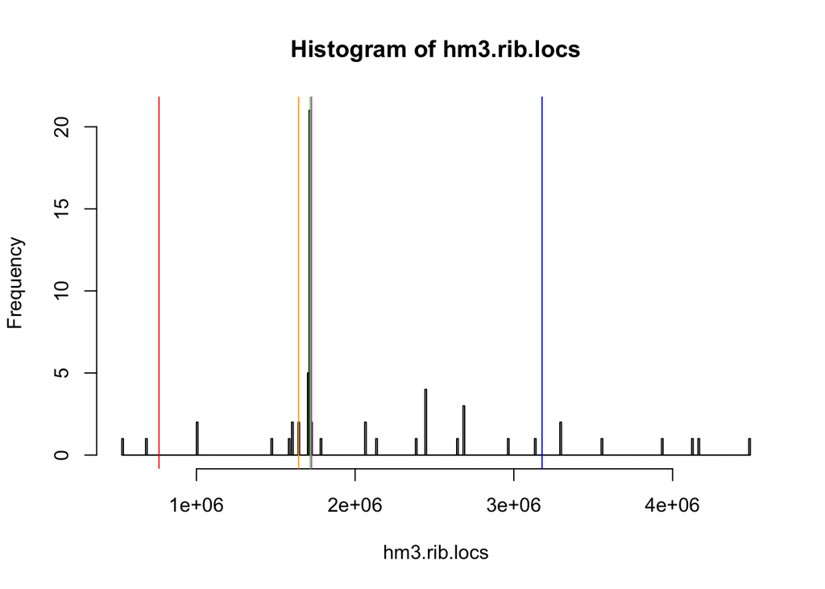

### Genes correlating with PTR

- Tried to figure out gene location on the chromosome (vs. contig as shown in gff file). Since the majority of genes were located on contig 1, those two were equivalent, and I decided to focus on only contig 1 genes for now.
- Load the data

```
##     gene_id genome contig contig_location
## 1 16489_gph   HM14      1         3395383
## 2 16489_gph   HM17      1         2995418
## 3 16489_gph    HM1      1         3157576
## 4 16489_gph    HM3      1         1759448
## 5 16489_gph   HM43      1         2764659
## 6 16489_gph   HM54      1          358801
```

- Look at each genome seperately
- Origin and terminus were determined with OriC
- Origin is shown in red, terminus in blue, nhoA in green, groL in magenta, (if terminus is of the axis, approximate location is shown in grey)
- HM14

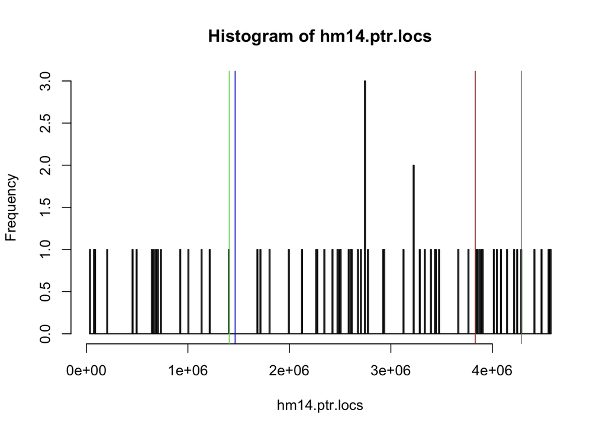

- HM3

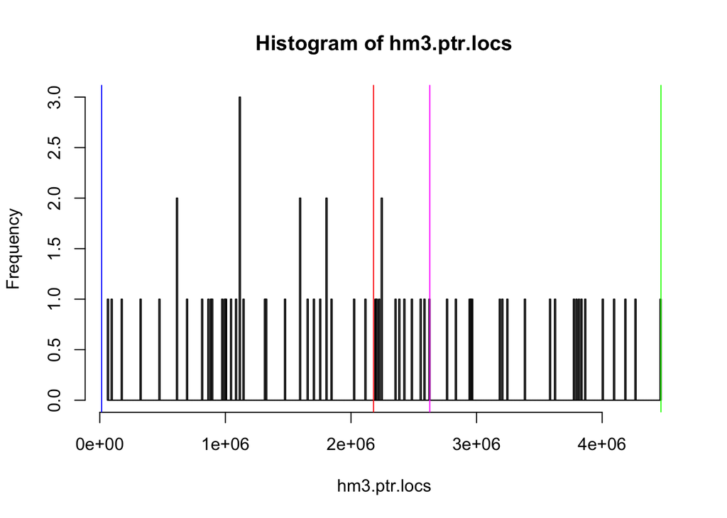

- HM17

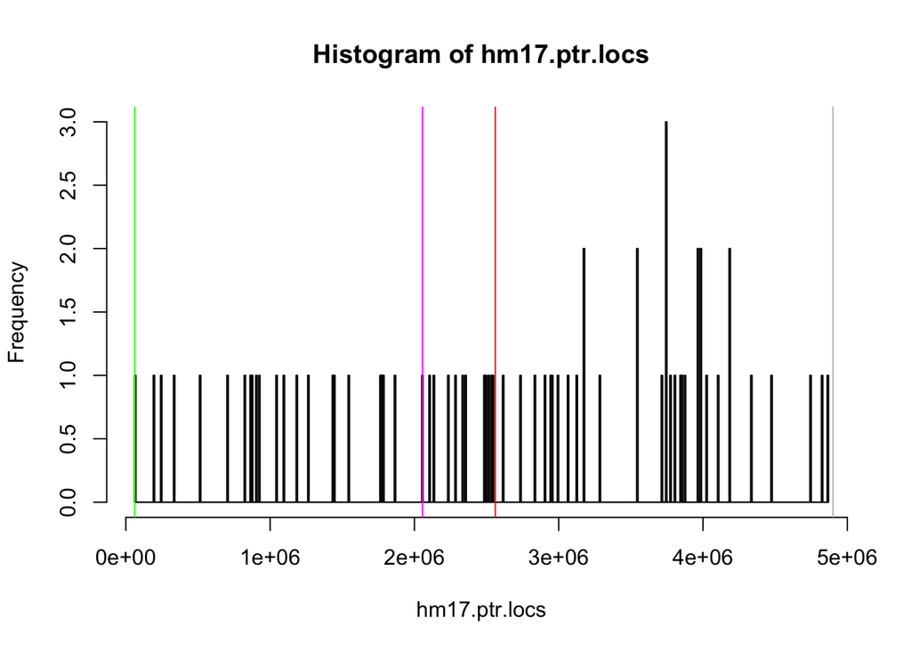

- Conclusion: No significant correlation between location of these genes and their relationship with PTR